# Economic determinants of crime in the world

27th of May, 2021

## The aim of the project

- **Reproduce** and **replicate** the results of a bachelor thesis study prepared in 2019 by Joanna Ceglińska (one of the project’s authors).

\[ \]

More precisely:

- we decided to check whether, based on the same initial data, we will obtain the same results,
- and whether the results are **robust** to changes in the initial assumptions and to expanding the dataset.

## Main modifications

- Different software (R and Python instead of STATA)
- New method of missing data imputation
- Extension of the dataset with new observations (from 2 consecutive years)
- Extension of the dataset with two new variables
- Implementing more advanced methods of data analysis and visualization

## Analyzing the problem

The main concern - poor economic situation in countries in Latin America.

Venezuela: an economic power after WWII, now it struggles with murders, kidnapping, drug dealing and other crimes.

Aren’t countries like the United States, Germany or Switzerland in danger of a similar situation?

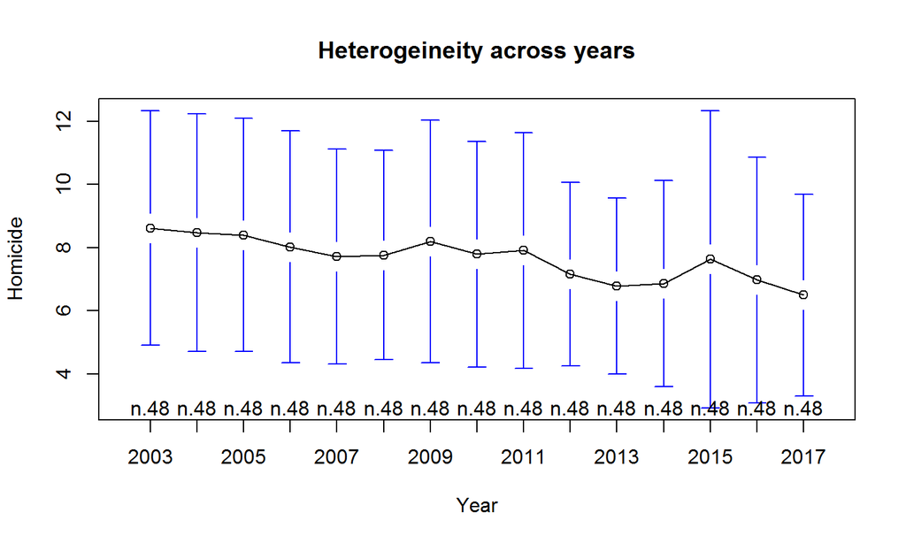

## The dependent variable

- The dependent variable is the **homicide rate**, which is the number of homicides (deaths caused by another person’s violence) per 100,000 population.
- A homicide is **not** equivalent to murder!
- Why this variable?
  - serious crime
  - available data
  - well tracked
  - reliable information
  - universal definition across cultures and countries

## Homicide rate distribution

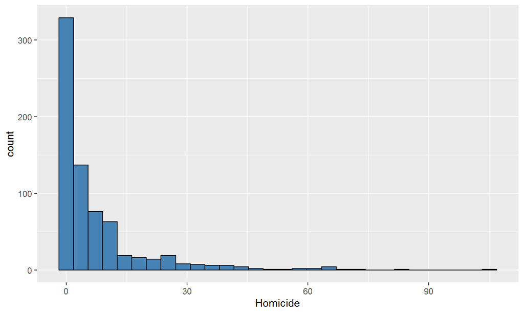

## Data

- Homicide rate as the dependent variable
- 48 countries

\[ \]

**Original dataset**

- Years 2003-2015
- 8 independent variables
- 624 observations in total

**Extended dataset**

- Years 2003-2017
- 8 + 2 independent variables:
  - Research and development expenditure
  - Urbanization rate
- 720 observations in total

## Independent variables

- Unsentenced detainees as a proportion of overall prison population
- Police personnel (per 100,000 population)
- Gini index (income inequality measure)
- Lower secondary completion rate (% of relevant age group)
- School enrollment, tertiary (% gross)
- Unemployment (% of total labor force) (national estimate)
- Compulsory education duration (years)
- GDP per capita (constant 2010 US$)
- **Research and development expenditure (% of GDP)**
- **Urban population (% of total population)**

## Data sources

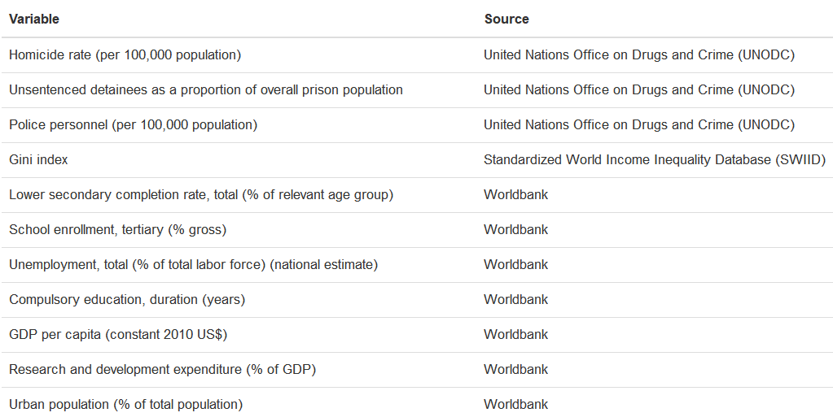

Additional sources:

- Research and development expenditure variable (Dominican Republic, 2013): Guzmán J. & Encarnación C., “Measuring and Promoting (R&D) Expenditure in Manufacturing Companies of High-Tech Healthcare Products in the Dominican Republic” (2015). Rochester Institute of Technology
- Tertiary school enrollment (Turkey, 2004-2015) : www.knoema.com

## Filling the missings value

**Previously:** manual way, prone to mistakes and errors in estimations - relying on trends in data

**Now:** moving average algorithm (2 period window) that fills in the blanks automatically based on existing values of observations

Advantages:

- consistent results
- fast, reusable algorithm
- unbiased when it comes to estimation

## Research hypotheses

**Positive impact (increase the crime level):**

- Unsentenced detainees as a proportion of overall prison population
- Unemployment rate
- Urban population

**Negative impact (decrease the crime level)**

- Income inequality (Gini index)
- GDP per capita
- Years of compulsory education
- Lower secondary education completion rate
- Tertiary school enrollment
- Police personnel
- Research and development expenditure

## Reproduction

## The schema of model selection

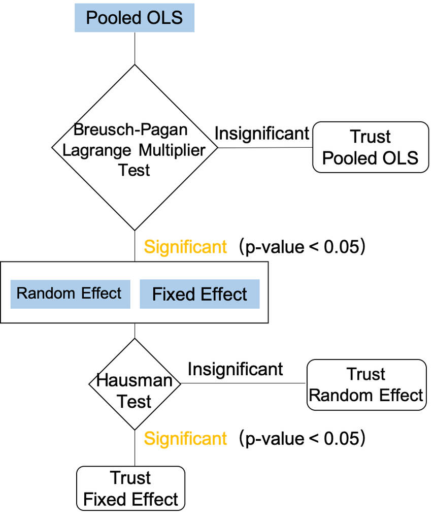

## Reproduction - model selection

| test | p.value | conclusion |
| --- | --- | --- |
| Breusch-Pagan LM test for random effects | < 0.0001 | significant random effects |
| F test for individual fixed effects | < 0.0001 | significant fixed effects |
| Breusch-Pagan LM test for time-fixed effects | 0.9982 | no time-fixed effects needed |
| Hausmann test | < 0.0001 | choose fixed effects model |

\[ \] \[ \Rightarrow \text{we choose} \mathbf{\text{ fixed effects model}} \]

## Fixed effects model

```
ln_Homicide ~ Inequality + Education_years + ln_GDP_per_capita +
    Lower_secondary_completion_rate + School_enrollment + Unemployment_int +
    Unsentenced + Police
```

```
t test of coefficients:

                                   Estimate  Std. Error t value  Pr(>|t|)
Inequality                       6.1961e-01  5.3246e-01  1.1637  0.245043
Education_years                  3.1942e-02  1.1668e-02  2.7375  0.006385 **
ln_GDP_per_capita               -7.9431e-01  1.2360e-01 -6.4263 2.774e-10 ***
Lower_secondary_completion_rate  2.2070e-03  2.2016e-03  1.0025  0.316546
School_enrollment               -3.4651e-03  1.5457e-03 -2.2417  0.025365 *
Unemployment_int_medium         -1.0319e-01  4.1535e-02 -2.4845  0.013262 *
Unemployment_int_high           -1.6476e-01  5.0838e-02 -3.2409  0.001262 **
Unsentenced                      5.5830e-03  1.7397e-03  3.2093  0.001406 **
Police                          -8.1719e-05  9.0060e-05 -0.9074  0.364591
---
Signif. codes:  0 '***' 0.001 '**' 0.01 '*' 0.05 '.' 0.1 ' ' 1
```

## General-to-specific procedure

```
t test of coefficients:

                                   Estimate  Std. Error t value  Pr(>|t|)
Inequality                       6.1961e-01  5.3246e-01  1.1637  0.245043
Education_years                  3.1942e-02  1.1668e-02  2.7375  0.006385 **
ln_GDP_per_capita               -7.9431e-01  1.2360e-01 -6.4263 2.774e-10 ***
Lower_secondary_completion_rate  2.2070e-03  2.2016e-03  1.0025  0.316546
School_enrollment               -3.4651e-03  1.5457e-03 -2.2417  0.025365 *
Unemployment_int_medium         -1.0319e-01  4.1535e-02 -2.4845  0.013262 *
Unemployment_int_high           -1.6476e-01  5.0838e-02 -3.2409  0.001262 **
Unsentenced                      5.5830e-03  1.7397e-03  3.2093  0.001406 **
Police                          -8.1719e-05  9.0060e-05 -0.9074  0.364591
---
Signif. codes:  0 '***' 0.001 '**' 0.01 '*' 0.05 '.' 0.1 ' ' 1
```

## General-to-specific procedure

```
t test of coefficients:

                           Estimate  Std. Error t value  Pr(>|t|)
Inequality               5.7979e-01  5.3098e-01  1.0919 0.2753253
Education_years          3.2705e-02  1.1643e-02  2.8089 0.0051422 **
ln_GDP_per_capita       -7.6493e-01  1.2008e-01 -6.3702 3.902e-10 ***
School_enrollment       -3.4841e-03  1.5456e-03 -2.2542 0.0245633 *
Unemployment_int_medium -1.1020e-01  4.0943e-02 -2.6914 0.0073244 **
Unemployment_int_high   -1.7008e-01  5.0560e-02 -3.3638 0.0008205 ***
Unsentenced              5.4327e-03  1.7332e-03  3.1345 0.0018102 **
Police                  -8.2342e-05  9.0058e-05 -0.9143 0.3609357
---
Signif. codes:  0 '***' 0.001 '**' 0.01 '*' 0.05 '.' 0.1 ' ' 1
```

- Lower_secondary_completion_rate

## General-to-specific procedure

```
t test of coefficients:

                          Estimate Std. Error t value  Pr(>|t|)
Inequality               0.5731796  0.5308496  1.0797 0.2807154
Education_years          0.0325391  0.0116402  2.7954 0.0053584 **
ln_GDP_per_capita       -0.7769427  0.1193427 -6.5102  1.65e-10 ***
School_enrollment       -0.0034778  0.0015454 -2.2505 0.0247994 *
Unemployment_int_medium -0.1119263  0.0408935 -2.7370 0.0063937 **
Unemployment_int_high   -0.1718482  0.0505159 -3.4019 0.0007163 ***
Unsentenced              0.0052976  0.0017266  3.0682 0.0022561 **
---
Signif. codes:  0 '***' 0.001 '**' 0.01 '*' 0.05 '.' 0.1 ' ' 1
```

- Lower_secondary_completion_rate
- Police

## General-to-specific procedure

```
t test of coefficients:

                          Estimate Std. Error t value  Pr(>|t|)
Education_years          0.0295422  0.0113061  2.6130  0.009213 **
ln_GDP_per_capita       -0.7802236  0.1193214 -6.5388 1.379e-10 ***
School_enrollment       -0.0034660  0.0015456 -2.2426  0.025309 *
Unemployment_int_medium -0.1032919  0.0401099 -2.5752  0.010268 *
Unemployment_int_high   -0.1597629  0.0492674 -3.2428  0.001253 **
Unsentenced              0.0051398  0.0017207  2.9871  0.002938 **
---
Signif. codes:  0 '***' 0.001 '**' 0.01 '*' 0.05 '.' 0.1 ' ' 1
```

- Lower_secondary_completion_rate
- Police
- Inequality

## Model diagnostic

```r
model_diagnostic(model1.3)
```

| test | p.value | conclusion |
| --- | --- | --- |
| Breusch-Pagan LM test for cross-sectional dependence | < 0.0001 | cross-sectional dependence |
| Pesaran CD test for cross-sectional dependence | 0.0416 | cross-sectional dependence |
| Breusch-Godfrey/Wooldridge test for serial correlation | < 0.0001 | serial correlation |
| Breusch-Pagan test for heteroskedasticity | < 0.0001 | heteroskedasticity |

\[ \] \[ \Rightarrow \text{appropriate robust estimator needed} \]

## Robust estimator

```r
coeftest(model1.3,
         vcovHC(model1.3, method = "arellano", type="HC0", cluster = "time"))
```

```
t test of coefficients:

                          Estimate Std. Error  t value  Pr(>|t|)
Education_years          0.0295422  0.0075117   3.9328 9.429e-05 ***
ln_GDP_per_capita       -0.7802236  0.0505100 -15.4469 < 2.2e-16 ***
School_enrollment       -0.0034660  0.0010922  -3.1733  0.001588 **
Unemployment_int_medium -0.1032919  0.0424590  -2.4327  0.015292 *
Unemployment_int_high   -0.1597629  0.0554727  -2.8800  0.004126 **
Unsentenced              0.0051398  0.0010378   4.9527 9.656e-07 ***
---
Signif. codes:  0 '***' 0.001 '**' 0.01 '*' 0.05 '.' 0.1 ' ' 1
```

## Bachelor thesis model

```r
model_Bachelor <- plm(ln_Homicide ~ Inequality + ln_GDP_per_capita +
                        School_enrollment + Police + Unsentenced,
                      data = df,
                      index = c("Country", "Year"),
                      model = "within")
```

| test | p.value | conclusion |
| --- | --- | --- |
| Breusch-Pagan LM test for cross-sectional dependence | < 0.0001 | cross-sectional dependence |
| Pesaran CD test for cross-sectional dependence | 8e-04 | cross-sectional dependence |
| Breusch-Godfrey/Wooldridge test for serial correlation | < 0.0001 | serial correlation |
| Breusch-Pagan test for heteroskedasticity | < 0.0001 | heteroskedasticity |

```
====================================================
                            Dependent variable:
                        ----------------------------

                           Bachelor    Reproduction
                             (1)            (2)
----------------------------------------------------
Inequality                  -0.127
                           (0.396)
Education_years                          0.030***
                                          (0.008)
ln_GDP_per_capita         -0.540***      -0.780***
                           (0.069)        (0.051)
School_enrollment         -0.004***      -0.003***
                           (0.001)        (0.001)
Police                     -0.0001
                           (0.0001)
Unemployment_int_medium                  -0.103**
                                          (0.042)
Unemployment_int_high                    -0.160***
                                          (0.055)
Unsentenced                0.005***      0.005***
                           (0.001)        (0.001)
====================================================
====================================================
Note:                    *p<0.1; **p<0.05; ***p<0.01
```

## Replication

### + 2 years / 96 observations

## Model selection

| test | p.value | conclusion |
| --- | --- | --- |
| Breusch-Pagan LM test for random effects | < 0.0001 | significant random effects |
| F test for individual fixed effects | < 0.0001 | significant fixed effects |
| Breusch-Pagan LM test for time-fixed effects | 0.4237 | no time-fixed effects needed |
| Hausmann test | < 0.0001 | choose fixed effects model |

\[ \] \[ \Rightarrow \text{we choose} \mathbf{\text{ fixed effects model}} \]

## Fixed effects model

```
ln_Homicide ~ Inequality + Education_years + ln_GDP_per_capita +
    Lower_secondary_completion_rate + School_enrollment + Unemployment_int +
    Unsentenced + Police
```

```
t test of coefficients:

                                   Estimate  Std. Error t value  Pr(>|t|)
Inequality                       5.1159e-01  5.2291e-01  0.9784 0.3282530
Education_years                  2.9525e-02  1.1174e-02  2.6423 0.0084289 **
ln_GDP_per_capita               -8.6323e-01  1.1464e-01 -7.5300 1.665e-13 ***
Lower_secondary_completion_rate  9.4362e-04  2.1532e-03  0.4382 0.6613517
School_enrollment               -3.2503e-03  1.4383e-03 -2.2599 0.0241522 *
Unemployment_int_medium         -8.9771e-02  3.9527e-02 -2.2711 0.0234585 *
Unemployment_int_high           -1.4326e-01  4.9315e-02 -2.9050 0.0037945 **
Unsentenced                      6.2713e-03  1.7493e-03  3.5850 0.0003619 ***
Police                           2.8680e-05  8.6922e-05  0.3300 0.7415362
---
Signif. codes:  0 '***' 0.001 '**' 0.01 '*' 0.05 '.' 0.1 ' ' 1
```

## General-to-specific procedure

```
t test of coefficients:

                          Estimate Std. Error t value  Pr(>|t|)
Education_years          0.0269738  0.0107440  2.5106 0.0122891 *
ln_GDP_per_capita       -0.8502380  0.1106538 -7.6838 5.545e-14 ***
School_enrollment       -0.0032791  0.0014339 -2.2869 0.0225167 *
Unemployment_int_medium -0.0851532  0.0383353 -2.2213 0.0266677 *
Unemployment_int_high   -0.1355166  0.0480441 -2.8207 0.0049350 **
Unsentenced              0.0061209  0.0017304  3.5373 0.0004324 ***
---
Signif. codes:  0 '***' 0.001 '**' 0.01 '*' 0.05 '.' 0.1 ' ' 1
```

- Lower_secondary_completion_rate
- Police
- Inequality

## Model diagnostic

```r
model_diagnostic(model2.3)
```

| test | p.value | conclusion |
| --- | --- | --- |
| Breusch-Pagan LM test for cross-sectional dependence | < 0.0001 | cross-sectional dependence |
| Pesaran CD test for cross-sectional dependence | 0.0394 | cross-sectional dependence |
| Breusch-Godfrey/Wooldridge test for serial correlation | < 0.0001 | serial correlation |
| Breusch-Pagan test for heteroskedasticity | < 0.0001 | heteroskedasticity |

\[ \] \[ \Rightarrow \text{appropriate robust estimator needed} \]

```
=====================================================================
                                     Dependent variable:
                        ---------------------------------------------
                              ln_Homicide
                                 panel               coefficient
                                linear                  test
                                                with robust estimator
                                  (1)                    (2)
---------------------------------------------------------------------
Education_years                 0.027**               0.027***
                                (0.011)                (0.007)
ln_GDP_per_capita              -0.850***              -0.850***
                                (0.111)                (0.061)
School_enrollment              -0.003**               -0.003***
                                (0.001)                (0.001)
Unemployment_int_medium        -0.085**               -0.085**
                                (0.038)                (0.041)
Unemployment_int_high          -0.136***              -0.136**
                                (0.048)                (0.054)
Unsentenced                    0.006***               0.006***
                                (0.002)                (0.001)
---------------------------------------------------------------------
Observations                      720
R2                               0.174
Adjusted R2                      0.108
F Statistic             23.329*** (df = 6; 666)
=====================================================================
Note:                                     *p<0.1; **p<0.05; ***p<0.01
```

## Replication

### + 2 years / 96 observations + 2 independent variables

## Model selection

| test | p.value | conclusion |
| --- | --- | --- |
| Breusch-Pagan LM test for random effects | < 0.0001 | significant random effects |
| F test for individual fixed effects | < 0.0001 | significant fixed effects |
| Breusch-Pagan LM test for time-fixed effects | 0.8936 | no time-fixed effects needed |
| Hausmann test | 0.0071 | choose fixed effects model |

\[ \] \[ \Rightarrow \text{we choose} \mathbf{\text{ fixed effects model}} \]

## Fixed effects model

```
ln_Homicide ~ Inequality + Education_years + ln_GDP_per_capita +
    Lower_secondary_completion_rate + School_enrollment + Unemployment_int +
    Unsentenced + Police + Urbanization_rate + ln_RnD_expenditure
```

```
t test of coefficients:

                                   Estimate  Std. Error t value  Pr(>|t|)
Inequality                       4.4440e-01  5.2171e-01  0.8518  0.394623
Education_years                  2.3405e-02  1.1999e-02  1.9506  0.051527 .
ln_GDP_per_capita               -9.7076e-01  1.2394e-01 -7.8322 1.915e-14 ***
Lower_secondary_completion_rate  2.8012e-04  2.1820e-03  0.1284  0.897887
School_enrollment               -3.9790e-03  1.5429e-03 -2.5789  0.010127 *
Unemployment_int_medium         -8.8745e-02  3.9634e-02 -2.2391  0.025480 *
Unemployment_int_high           -1.6040e-01  5.1190e-02 -3.1333  0.001805 **
Unsentenced                      5.5523e-03  1.7690e-03  3.1387  0.001773 **
Police                           4.6088e-05  8.7338e-05  0.5277  0.597887
Urbanization_rate                2.0245e-02  9.1385e-03  2.2154  0.027073 *
ln_RnD_expenditure              -6.2045e-02  4.9062e-02 -1.2646  0.206450
---
Signif. codes:  0 '***' 0.001 '**' 0.01 '*' 0.05 '.' 0.1 ' ' 1
```

## General-to-specific procedure

```
t test of coefficients:

                          Estimate Std. Error t value  Pr(>|t|)
Education_years          0.0180820  0.0113328  1.5955 0.1110659
ln_GDP_per_capita       -0.9703507  0.1211542 -8.0092 5.173e-15 ***
School_enrollment       -0.0044053  0.0015044 -2.9284 0.0035241 **
Unemployment_int_medium -0.0874323  0.0382119 -2.2881 0.0224451 *
Unemployment_int_high   -0.1616546  0.0491052 -3.2920 0.0010474 **
Unsentenced              0.0058437  0.0017282  3.3814 0.0007634 ***
Urbanization_rate        0.0212269  0.0088721  2.3925 0.0170084 *
---
Signif. codes:  0 '***' 0.001 '**' 0.01 '*' 0.05 '.' 0.1 ' ' 1
```

- Lower_secondary_completion_rate
- Police
- Inequality
- ln_RnD_expenditure

## Model diagnostic

```r
model_diagnostic(model3.4)
```

| test | p.value | conclusion |
| --- | --- | --- |
| Breusch-Pagan LM test for cross-sectional dependence | < 0.0001 | cross-sectional dependence |
| Pesaran CD test for cross-sectional dependence | 0.0145 | cross-sectional dependence |
| Breusch-Godfrey/Wooldridge test for serial correlation | < 0.0001 | serial correlation |
| Breusch-Pagan test for heteroskedasticity | < 0.0001 | heteroskedasticity |

\[ \] \[ \Rightarrow \text{appropriate robust estimator needed} \]

```
=====================================================================
                                     Dependent variable:
                        ---------------------------------------------
                              ln_Homicide
                                 panel               coefficient
                                linear                  test
                                                with robust estimator
                                  (1)                    (2)
---------------------------------------------------------------------
Education_years                  0.018                0.018***
                                (0.011)                (0.007)
ln_GDP_per_capita              -0.970***              -0.970***
                                (0.121)                (0.068)
School_enrollment              -0.004***              -0.004***
                                (0.002)                (0.001)
Unemployment_int_medium        -0.087**               -0.087**
                                (0.038)                (0.042)
Unemployment_int_high          -0.162***              -0.162***
                                (0.049)                (0.050)
Unsentenced                    0.006***               0.006***
                                (0.002)                (0.001)
Urbanization_rate               0.021**               0.021***
                                (0.009)                (0.008)
---------------------------------------------------------------------
Observations                      720
R2                               0.181
Adjusted R2                      0.114
F Statistic             20.956*** (df = 7; 665)
=====================================================================
Note:                                     *p<0.1; **p<0.05; ***p<0.01
```

## Conclusion

```
==========================================================================
                                       Dependent variable:
                        --------------------------------------------------

                        Bachelor  Reproduction Replication 1 Replication 2
                           (1)        (2)           (3)           (4)
--------------------------------------------------------------------------
Inequality               -0.127
                         (0.396)
Education_years                     0.030***     0.027***      0.018***
                                    (0.008)       (0.007)       (0.007)
ln_GDP_per_capita       -0.540***  -0.780***     -0.850***     -0.970***
                         (0.069)    (0.051)       (0.061)       (0.068)
School_enrollment       -0.004***  -0.003***     -0.003***     -0.004***
                         (0.001)    (0.001)       (0.001)       (0.001)
Police                   -0.0001
                        (0.0001)
Unemployment_int_medium             -0.103**     -0.085**      -0.087**
                                    (0.042)       (0.041)       (0.042)
Unemployment_int_high              -0.160***     -0.136**      -0.162***
                                    (0.055)       (0.054)       (0.050)
Unsentenced             0.005***    0.005***     0.006***      0.006***
                         (0.001)    (0.001)       (0.001)       (0.001)
Urbanization_rate                                              0.021***
                                                                (0.008)
==========================================================================
==========================================================================
Note:                                          *p<0.1; **p<0.05; ***p<0.01
```

## Verification of hypotheses

[output not shown]

## Conclusions

- The model from the bachelor thesis differed significantly from the models we estimated.
- Reproduction and replications gave very similar results to each other.
- Adding *Urbanization_rate* in the replication part improved the model and **did** change values of some estimators, but not the general conclusion.
- Some of the hypotheses verified in the bachelor thesis were not verified by our reproducible research.
- The project strongly emphasizes the importance of proper data preparation and precise filling of missing values.

## Thank you for your attention!